# Dr. Waldrop’s Odor-capture Notebook

# Some initial plotting for the water condition

Loading data and shaping data frame:

```r
library(ggplot2) # for ggplots
library(cowplot) # for plot_grid()
library(reshape2) # for melt()
library(viridis) # for the viridis color palette
# Sourcing data handling functions
source("../src/r-scripts/datahandling_functions.R")

n <- 165 # Number of simulations in set

# Loading individual data sets
waterdata_3 <- loadnshapedata(n,"totalconc_water",3,"2020-12-08")
waterdata_18 <- loadnshapedata(n,"totalconc_water",18,"2020-12-04")
waterdata_25 <- loadnshapedata(n,"totalconc_water",25,"2020-12-04")
airdata_3 <- loadnshapedata(n,"totalconc_air",3,"2020-12-08")
airdata_18 <- loadnshapedata(n,"totalconc_air",18,"2020-12-04")
airdata_25 <- loadnshapedata(n,"totalconc_air",25,"2020-12-04")

water.data <- list("3" = waterdata_3, "18" = waterdata_18, "25" = waterdata_25)
air.data <- list("3" = airdata_3, "18" = airdata_18, "25" = airdata_25)
list.hairs <- c("3","18","25")
alldatarow.water<-stitch.rows(water.data,list.hairs)
alldatarow.air<-stitch.rows(air.data,list.hairs)
```

## Preliminary Results

### 1. It’s better to have more hairs in water and fewer hairs in air.

We can set up data frames that will compare for us in separate plots the total odor concentration caught by each array in air or water.

```r
alldatawater.totalconc <- data.frame(waterdata_3[,1:3], waterdata_3$total.conc,
                                     waterdata_18$total.conc, waterdata_25$total.conc)
colnames(alldatawater.totalconc)<- c(colnames(waterdata_3[,1:3]),
                                     "3hairs","18hairs","25hairs")
alldatawaterconc.melted <- melt(alldatawater.totalconc,
                                id.vars = c("angle","gap","Re"))
alldataair.totalconc <- data.frame(airdata_3[,1:3], airdata_3$total.conc,
                                   airdata_18$total.conc, airdata_25$total.conc)
colnames(alldataair.totalconc)<- c(colnames(airdata_3[,1:3]),
                                   "3hairs","18hairs","25hairs")
alldataairconc.melted <- melt(alldataair.totalconc,
                              id.vars = c("angle","gap","Re"))
```

From here, we can plot the mean total concentration captured by each array for water and air:

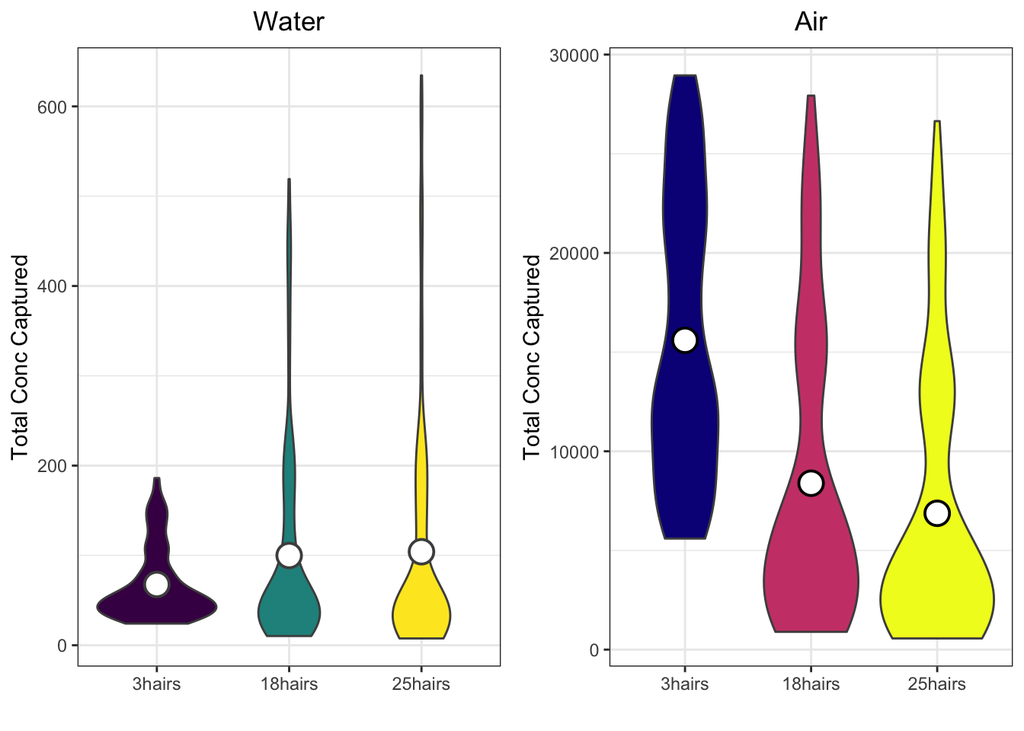

Here we can see that in water, it’s slightly better to have more hairs, and in some cases, a lot better. The 3-hair array captures significantly less odor than the 18-hair array ($t = -3.44$, $p = 7\times 10^{-4}$) and the 25-hair array ($t = -3.38$, $p = 9\times 10^{-4}$). The odor captured by the 18-hair and 25-hair arrays was not different from each other ($t = -0.309$, $p = 0.8$).

However, in air it’s generally better to have fewer hairs. Even though there is less surface area available to capture odor, totals were on average higher for the 3-hair array than for 18-hair ($t = 9.07$, $p = 10^{-17}$) or 25-hair ($t = 11.5$, $p = 8\times 10^{-26}$) arrays. Once again, odor captured by the 18-hair and 25-hair arrays were not different from each other ($t = 1.95$, $p = 0.05$).

We can also plot the total concentration captured against each of the three parameters for air and water:

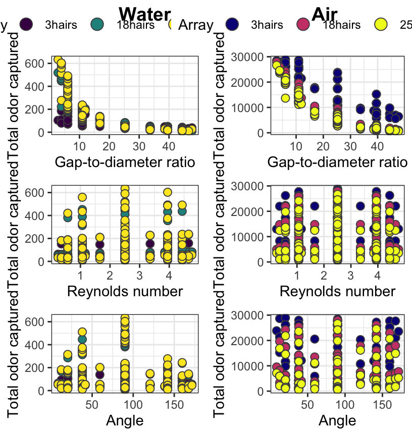

## 2. Outer hairs shield inner hairs from capturing odor in air (but not water)

Plot gap-to-diameter ratio against value:

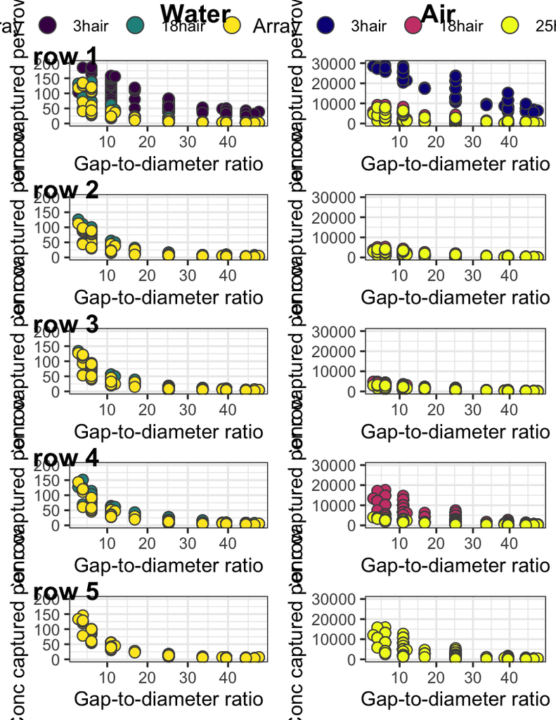

Plot Reynolds number against odor captured:

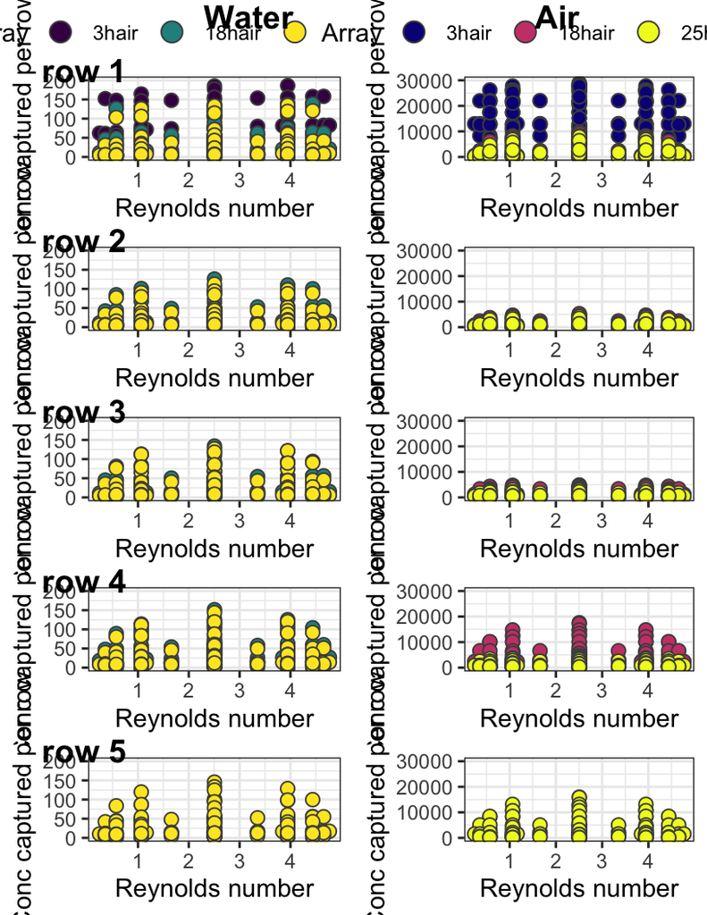

Plot angle against value:

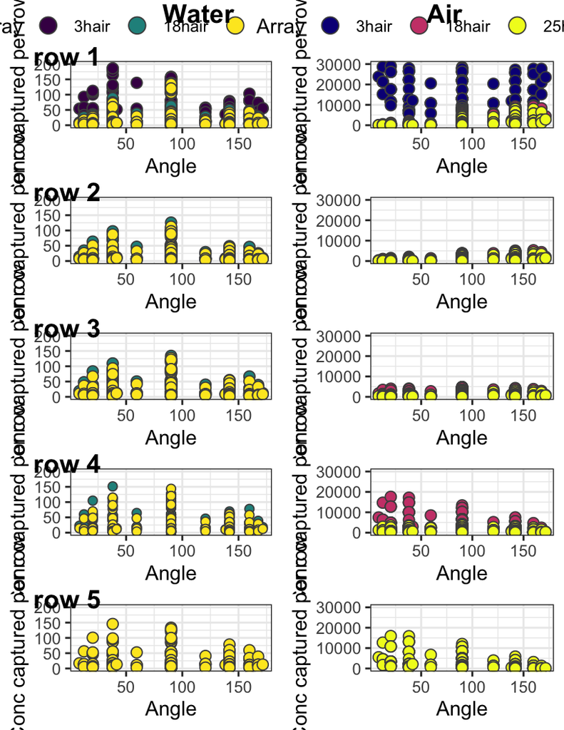